# TMDB 5000 Movie Dataset 分析

Yen Lung Wang

2019/7/22

# 資料來源

[Kaggle dataset: TMDB 5000 Movie Dataset](https://www.kaggle.com/tmdb/tmdb-movie-metadata)

# 資料欄位內容

## movie_metadata.csv

| Feature Name | 描述 |
| --- | --- |
| movie_title | 電影名稱 |
| duration | 片長（分鐘） |
| director_name | 導演名稱 |
| director_facebook_likes | 導演臉書專頁按讚數 |
| actor_1_name | 主角名稱 |
| actor_1_facebook_likes | 主角臉書專頁按讚數 |
| actor_2_name | 第二主角名稱 |
| actor_2_facebook_likes | 第二主角臉書專頁按讚數 |
| actor_3_name | 第三主角名稱 |
| actor_3_facebook_likes | 第三主角臉書專頁按讚數 |
| num_user_for_reviews | 在 imdb 上給 review 的人數 |
| num_critic_for_reviews | 在 imdb 上給 critic review 的人數 |
| num_voted_users | 在 imdb 上給 vote 的人數 |
| cast_total_facebook_likes | 所有卡司的臉書專頁總按讚數 |
| movie_facebook_likes | 電影臉書專頁的按讚數 |
| plot_keywords | 電影內容的關鍵字：‘avatar’, ‘future’, ‘alien’ |
| facenumber_in_poster | 電影海報上出現的角色人數（有露臉） |
| color | 電影形式：‘Black and White’ 或 ‘Color’ |
| genres | 電影分類：‘Animation’, ‘Comedy’, ‘Romance’, ‘Horror’, ‘Sci-Fi’, ‘Action’, ‘Family’ |
| title_year | 電影上映的年代 (1916:2016) |
| language | 電影支援的語系：English, Arabic, Chinese, French, German, Danish, Italian, Japanese…. |
| country | 電影製造國家 |
| content_rating | 電影分級 |
| aspect_ratio | 電影畫面長寬比 |
| movie_imdb_link | 電影的 imdb 連結 |
| gross | 電影總收入 Dollars |
| budget | 電影製造成本 Dollars |
| imdb_score | IMDB 分數 |

# 分析流程：

- 資料取得
- 資料前處理
- 資料探索
- 分析

# 欲分析問題

- 票房是否與 IMDb 分數有直接關係？
- 演員的知名度是否會影響 IMDb 的分數？

# 資料取得

## 載入 library

```r
library(ggplot2)
library(dplyr)
library(magrittr)
library(ggrepel)
```

## 載入資料

```r
imdb_df <- read.csv('./input/movie_metadata.csv')
head(imdb_df)
```

```
##   color     director_name num_critic_for_reviews duration
## 1 Color     James Cameron                    723      178
## 2 Color    Gore Verbinski                    302      169
## 3 Color        Sam Mendes                    602      148
## 4 Color Christopher Nolan                    813      164
## 5             Doug Walker                     NA       NA
## 6 Color    Andrew Stanton                    462      132
##   director_facebook_likes actor_3_facebook_likes     actor_2_name
## 1                       0                    855 Joel David Moore
## 2                     563                   1000    Orlando Bloom
## 3                       0                    161     Rory Kinnear
## 4                   22000                  23000   Christian Bale
## 5                     131                     NA       Rob Walker
## 6                     475                    530  Samantha Morton
##   actor_1_facebook_likes     gross                          genres
```

[output cut: 62 more lines]

```r
dim <- dim(imdb_df)
paste('此資料集共有' , dim[2] , '個 feature, ' , dim[1], '筆資料')
```

```
## [1] "此資料集共有 28 個 feature,  5043 筆資料"
```

# 資料前處理

## 數據清理

### 刪除重複值

```r
paste('共有' , sum(duplicated(imdb_df)), '筆重複的資料')
```

```
## [1] "共有 45 筆重複的資料"
```

```r
imdb_df <- imdb_df[!duplicated(imdb_df), ]
dim <- dim(imdb_df)
paste('刪除重複值後，資料集目前共有', dim[1], '筆資料')
```

```
## [1] "刪除重複值後，資料集目前共有 4998 筆資料"
```

### 處理缺失值

```r
colSums(sapply(imdb_df, is.na))
```

```
##                     color             director_name
##                         0                         0
##    num_critic_for_reviews                  duration
##                        49                        15
##   director_facebook_likes    actor_3_facebook_likes
##                       103                        23
##              actor_2_name    actor_1_facebook_likes
##                         0                         7
##                     gross                    genres
##                       874                         0
##              actor_1_name               movie_title
##                         0                         0
##           num_voted_users cast_total_facebook_likes
##                         0                         0
##              actor_3_name      facenumber_in_poster
##                         0                        13
##             plot_keywords           movie_imdb_link
##                         0                         0
##      num_user_for_reviews                  language
##                        21                         0
##                   country            content_rating
##                         0                         0
##                    budget                title_year
##                       487                       107
##    actor_2_facebook_likes                imdb_score
##                        13                         0
##              aspect_ratio      movie_facebook_likes
##                       327                         0
```

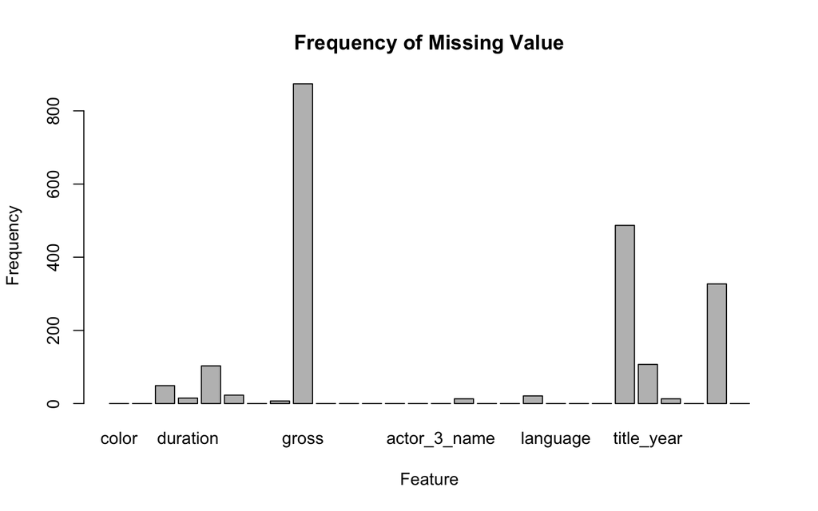

```r
barplot(colSums(sapply(imdb_df, is.na)), main="Frequency of Missing Value", xlab="Feature", ylab="Frequency")
```

N/A 最多的 feature 出現在 gross 和 budget

因為筆數過多，將 gross, budget 內 N/A 的資料刪除。

```r
imdb_df <- imdb_df[!is.na(imdb_df$gross), ]
imdb_df <- imdb_df[!is.na(imdb_df$budget), ]
dim(imdb_df)
```

```
## [1] 3857   28
```

```r
paste('將 gross 和 budget 為缺失值的資料刪除後，目前剩下' , dim(imdb_df)[1], '筆資料')
```

```
## [1] "將 gross 和 budget 為缺失值的資料刪除後，目前剩下 3857 筆資料"
```

```r
paste(dim(imdb_df)[1], '筆資料中，尚還有' , dim(imdb_df)[1]-sum(complete.cases(imdb_df)), '筆資料包含缺失值')
```

```
## [1] "3857 筆資料中，尚還有 89 筆資料包含缺失值"
```

```r
colSums(sapply(imdb_df, is.na))
```

```
##                     color             director_name
##                         0                         0
##    num_critic_for_reviews                  duration
##                         1                         1
##   director_facebook_likes    actor_3_facebook_likes
##                         0                        10
##              actor_2_name    actor_1_facebook_likes
##                         0                         3
##                     gross                    genres
##                         0                         0
##              actor_1_name               movie_title
##                         0                         0
##           num_voted_users cast_total_facebook_likes
##                         0                         0
##              actor_3_name      facenumber_in_poster
##                         0                         6
##             plot_keywords           movie_imdb_link
##                         0                         0
##      num_user_for_reviews                  language
##                         0                         0
##                   country            content_rating
##                         0                         0
##                    budget                title_year
##                         0                         0
##    actor_2_facebook_likes                imdb_score
##                         5                         0
##              aspect_ratio      movie_facebook_likes
##                        74                         0
```

接著來處理 aspect-ratio 內的缺失值

```r
table(imdb_df$aspect_ratio)
```

```
##
## 1.18 1.33 1.37  1.5 1.66 1.75 1.77 1.78 1.85    2  2.2 2.24 2.35 2.39  2.4
##    1   19   50    1   40    2    1   41 1600    3   10    1 1995   11    3
## 2.55 2.76   16
##    1    3    1
```

可看出大部分的 aspect-ration 位於 1.85 和 2.35 ，數量皆高達 1500 以上，接近 2000。 而因為 缺失值佔的比例太小，在此簡便處理，直接將其刪除。

```r
imdb_df <- imdb_df[!is.na(imdb_df$aspect_ratio), ]
paste('將 aspect-ratio 為缺失值的資料刪除後，目前剩下' , dim(imdb_df)[1], '筆資料')
```

```
## [1] "將 aspect-ratio 為缺失值的資料刪除後，目前剩下 3783 筆資料"
```

```r
colSums(sapply(imdb_df, is.na))
```

```
##                     color             director_name
##                         0                         0
##    num_critic_for_reviews                  duration
##                         1                         0
##   director_facebook_likes    actor_3_facebook_likes
##                         0                         8
##              actor_2_name    actor_1_facebook_likes
##                         0                         1
##                     gross                    genres
##                         0                         0
##              actor_1_name               movie_title
##                         0                         0
##           num_voted_users cast_total_facebook_likes
##                         0                         0
##              actor_3_name      facenumber_in_poster
##                         0                         6
##             plot_keywords           movie_imdb_link
##                         0                         0
##      num_user_for_reviews                  language
##                         0                         0
##                   country            content_rating
##                         0                         0
##                    budget                title_year
##                         0                         0
##    actor_2_facebook_likes                imdb_score
##                         3                         0
##              aspect_ratio      movie_facebook_likes
##                         0                         0
```

處理剩餘的缺失值，皆用平均值補上

```r
imdb_df$facenumber_in_poster[is.na(imdb_df$facenumber_in_poster)] <- round(mean(imdb_df$facenumber_in_poster, na.rm = TRUE))
imdb_df$actor_3_facebook_likes[is.na(imdb_df$actor_3_facebook_likes)] <- round(mean(imdb_df$actor_3_facebook_likes, na.rm = TRUE))
imdb_df$num_critic_for_reviews[is.na(imdb_df$num_critic_for_reviews)] <- round(mean(imdb_df$num_critic_for_reviews, na.rm = TRUE))
imdb_df$actor_1_facebook_likes[is.na(imdb_df$actor_1_facebook_likes)] <- round(mean(imdb_df$actor_1_facebook_likes, na.rm = TRUE))
imdb_df$actor_2_facebook_likes[is.na(imdb_df$actor_2_facebook_likes)] <- round(mean(imdb_df$actor_2_facebook_likes, na.rm = TRUE))
colSums(sapply(imdb_df, is.na))
```

```
##                     color             director_name
##                         0                         0
##    num_critic_for_reviews                  duration
##                         0                         0
##   director_facebook_likes    actor_3_facebook_likes
##                         0                         0
##              actor_2_name    actor_1_facebook_likes
##                         0                         0
##                     gross                    genres
##                         0                         0
##              actor_1_name               movie_title
##                         0                         0
##           num_voted_users cast_total_facebook_likes
##                         0                         0
##              actor_3_name      facenumber_in_poster
##                         0                         0
##             plot_keywords           movie_imdb_link
##                         0                         0
##      num_user_for_reviews                  language
##                         0                         0
##                   country            content_rating
##                         0                         0
##                    budget                title_year
##                         0                         0
##    actor_2_facebook_likes                imdb_score
##                         0                         0
##              aspect_ratio      movie_facebook_likes
##                         0                         0
```

接著，為了後續分析方便，加上 profit, return_on_investment_perc 欄位

```r
imdb_df$profit <- (imdb_df$gross - imdb_df$budget)
imdb_df$return_on_investment_perc <- (imdb_df$profit / imdb_df$budget)*100
head(imdb_df)
```

```
##   color     director_name num_critic_for_reviews duration
## 1 Color     James Cameron                    723      178
## 2 Color    Gore Verbinski                    302      169
## 3 Color        Sam Mendes                    602      148
## 4 Color Christopher Nolan                    813      164
## 6 Color    Andrew Stanton                    462      132
## 7 Color         Sam Raimi                    392      156
##   director_facebook_likes actor_3_facebook_likes     actor_2_name
## 1                       0                    855 Joel David Moore
## 2                     563                   1000    Orlando Bloom
## 3                       0                    161     Rory Kinnear
## 4                   22000                  23000   Christian Bale
## 6                     475                    530  Samantha Morton
## 7                       0                   4000     James Franco
##   actor_1_facebook_likes     gross                          genres
```

[output cut: 62 more lines]

# 資料探索

將數值類的 feature 間畫出散步圖觀察趨勢

```r
numeric_features <- c()
for(i in 1:dim(imdb_df)[2])
{
  if(is.numeric(imdb_df[,i])|| is.integer(imdb_df[,i]))
  {
    numeric_features <- c(numeric_features, i)
  }
}
numeric_features
```

```
##  [1]  3  4  5  6  8  9 13 14 16 19 23 24 25 26 27 28 29 30
```

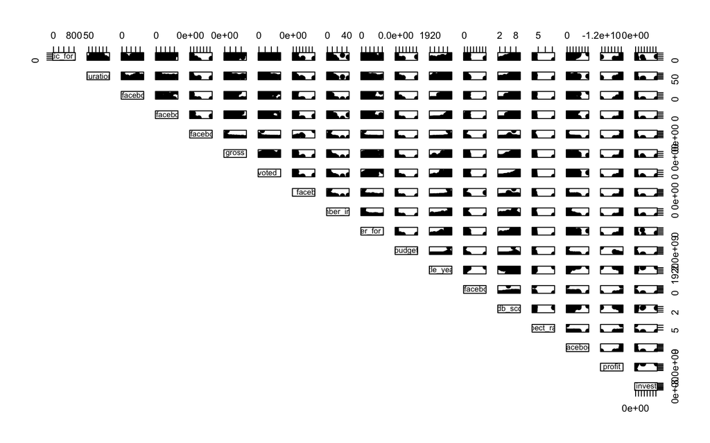

```r
pairs(imdb_df[,numeric_features], pch = 19, lower.panel = NULL)
```

看起來有些 feature 間有趨勢，接著更詳細的看看 correlation matrix

```r
corr_matrix <- cor(imdb_df[,numeric_features])
corr_matrix
```

```
##                           num_critic_for_reviews     duration
## num_critic_for_reviews                1.00000000  0.230412924
## duration                              0.23041292  1.000000000
## director_facebook_likes               0.17685401  0.179236524
## actor_3_facebook_likes                0.24686143  0.120538201
## actor_1_facebook_likes                0.16935137  0.084621704
## gross                                 0.46704104  0.244773192
## num_voted_users                       0.59531920  0.340054411
## cast_total_facebook_likes             0.23782008  0.119592235
## facenumber_in_poster                 -0.03454377  0.030534466
## num_user_for_reviews                  0.56684466  0.352832047
## budget                                0.10527378  0.068038415
## title_year                            0.40846638 -0.128914024
## actor_2_facebook_likes                0.25308610  0.127444404
## imdb_score                            0.34484206  0.366142557
## aspect_ratio                          0.18136923  0.155258208
## movie_facebook_likes                  0.70318418  0.217073713
## profit                                0.03847942  0.007514554
## return_on_investment_perc             0.03262104 -0.033128590
##                           director_facebook_likes actor_3_facebook_likes
## num_critic_for_reviews                0.176854008             0.24686143
## duration                              0.179236524             0.12053820
## director_facebook_likes               1.000000000             0.12149135
## actor_3_facebook_likes                0.121491349             1.00000000
## actor_1_facebook_likes                0.091860671             0.25382212
## gross                                 0.140980336             0.28240547
## num_voted_users                       0.303244832             0.25897532
## cast_total_facebook_likes             0.121623888             0.48641837
## facenumber_in_poster                 -0.046846547             0.10352818
## num_user_for_reviews                  0.219975375             0.20233439
## budget                                0.018519509             0.03878211
## title_year                           -0.045214913             0.11330878
## actor_2_facebook_likes                0.118920212             0.55074363
## imdb_score                            0.191120573             0.06376330
## aspect_ratio                          0.037820310             0.04864365
## movie_facebook_likes                  0.161754240             0.25893310
## profit                                0.024654280             0.04772956
## return_on_investment_perc            -0.006429122            -0.01249460
##                           actor_1_facebook_likes       gross
## num_critic_for_reviews                0.16935137  0.46704104
```

[output cut: 97 more lines]

```
## actor_3_facebook_likes     0.047729559              -0.012494595
## actor_1_facebook_likes     0.027770388              -0.015880187
## gross                      0.205992840               0.018347769
## num_voted_users            0.124621329               0.010088544
## cast_total_facebook_likes  0.042166863              -0.018938678
## facenumber_in_poster       0.011352919              -0.013504604
## num_user_for_reviews       0.096584899               0.068187567
## budget                    -0.953133261              -0.008066737
## title_year                -0.029342851              -0.016047228
## actor_2_facebook_likes     0.039936819              -0.013998919
## imdb_score                 0.035644844               0.009844455
## aspect_ratio              -0.004600349              -0.041894867
## movie_facebook_likes       0.059248595              -0.003102612
## profit                     1.000000000               0.013512222
## return_on_investment_perc  0.013512222               1.000000000
```

```r
# which(abs(corr_matrix) >= 0.5, arr.ind = T)
```

由 corr_matrix 中可看出，許多 feature 間的組合都有共線性的問題，會讓 feature 對模型的解釋能力產生影響。

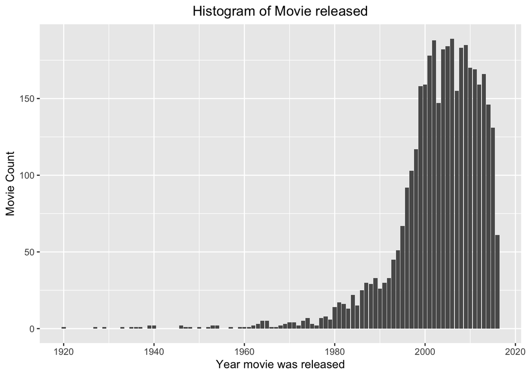

```r
ggplot(imdb_df, aes(title_year)) +
  geom_bar() +
  labs(x = "Year movie was released", y = "Movie Count", title = "Histogram of Movie released") +
  theme(plot.title = element_text(hjust = 0.5))
```

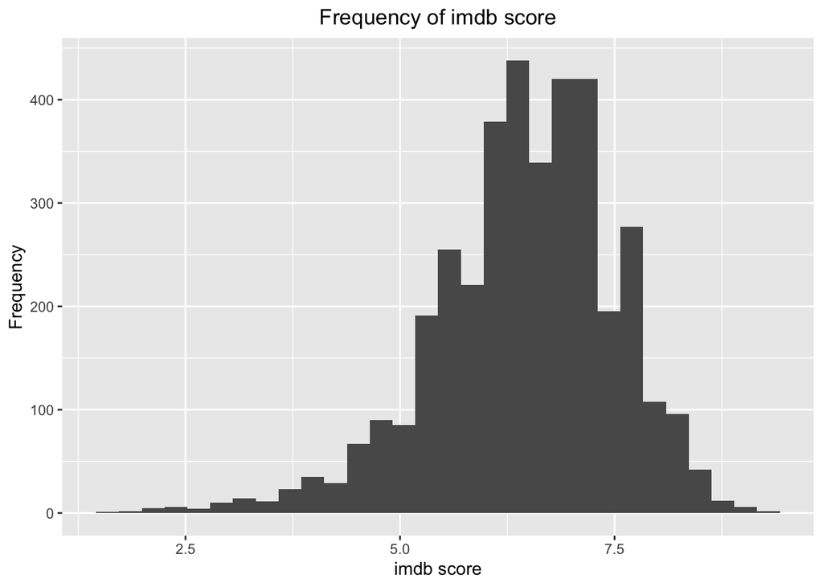

```r
ggplot(imdb_df, aes(x=imdb_score)) + geom_histogram() +
  labs(x = "imdb score", y = "Frequency", title = "Frequency of imdb score") +
  theme(plot.title = element_text(hjust = 0.5))
```

可看出 imdb score 大部分分佈在 5.0 ~ 7.5 之間。

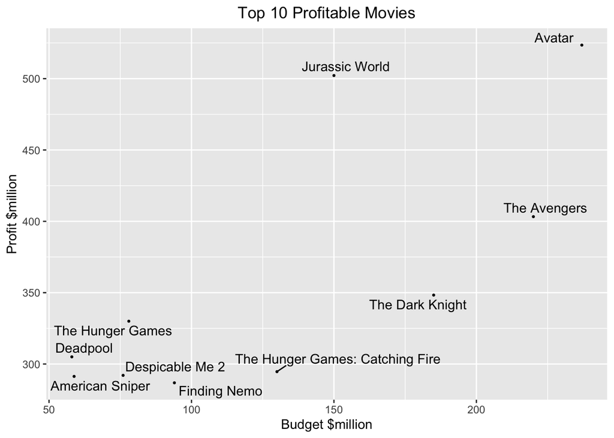

```r
imdb_df %>%
  filter(title_year %in% c(2000:2016)) %>%
  arrange(desc(profit)) %>%
  top_n(10, profit) %>%
  ggplot(aes(x=budget/1000000, y=profit/1000000)) +
  geom_point(size=0.5) +
  geom_text_repel(aes(label=movie_title)) +
  labs(x = "Budget $million", y = "Profit $million", title = "Top 10 Profitable Movies") +
  theme(plot.title = element_text(hjust = 0.5))
```

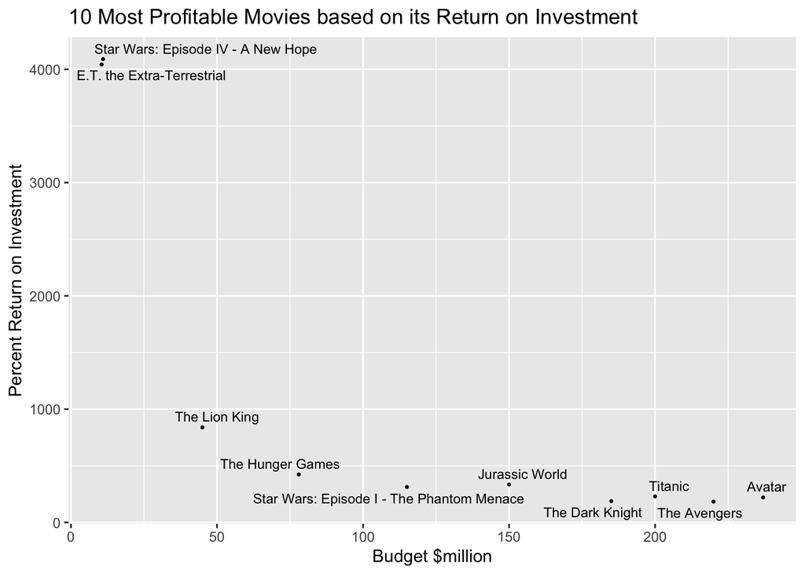

```r
imdb_df %>%
  filter(budget > 100000) %>%
  mutate(profit = gross - budget,
         return_on_investment_perc = (profit/budget)*100) %>%
  arrange(desc(profit)) %>%
  top_n(10, profit) %>%
  ggplot(aes(x=budget/1000000, y = return_on_investment_perc)) +
  geom_point(size = 0.5) +
  geom_text_repel(aes(label = movie_title), size = 3) +
  labs(x = "Budget $million", y = "Percent Return on Investment", title = "10 Most Profitable Movies based on its Return on Investment")
```

可看出 Star War: Eposode IV - A New Hope 的 ROI 大於其他電影。

# 分析

## 票房是否與 IMDb 分數有直接關係？

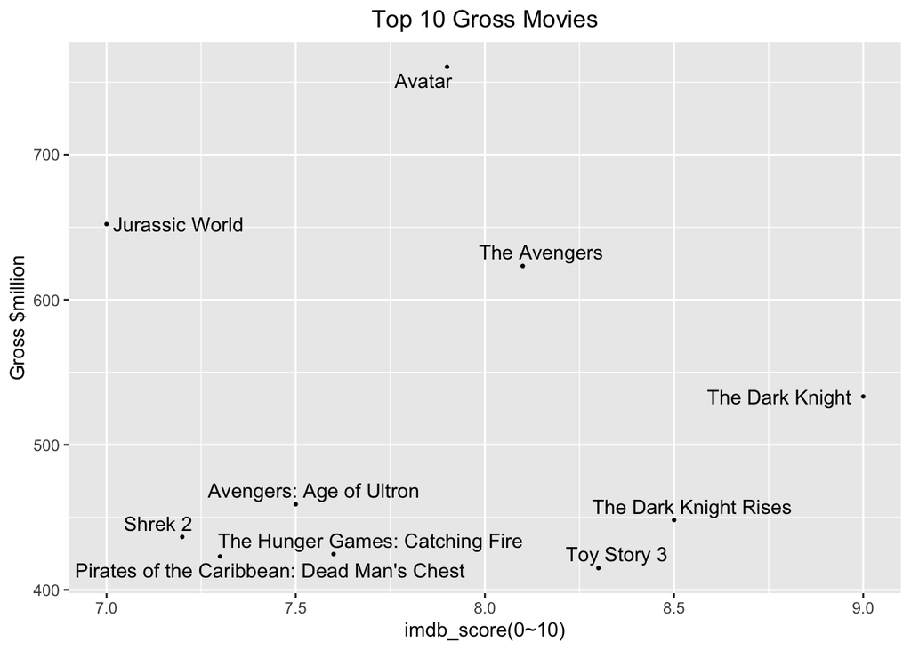

```r
imdb_df %>%
  filter(title_year %in% c(2000:2016)) %>%
  arrange(desc(gross)) %>%
  top_n(10, gross) %>%
  ggplot(aes(x=imdb_score, y=gross/1000000)) +
  geom_point(size=0.5) +
  geom_text_repel(aes(label=movie_title)) +
  labs(x = "imdb_score(0~10)", y = "Gross $million", title = "Top 10 Gross Movies") +
  theme(plot.title = element_text(hjust = 0.5))
```

票房越高，不代表 IMDb score 越高。兩者並無顯著的直接關係。

## 演員的知名度是否會影響 IMDb 的分數？

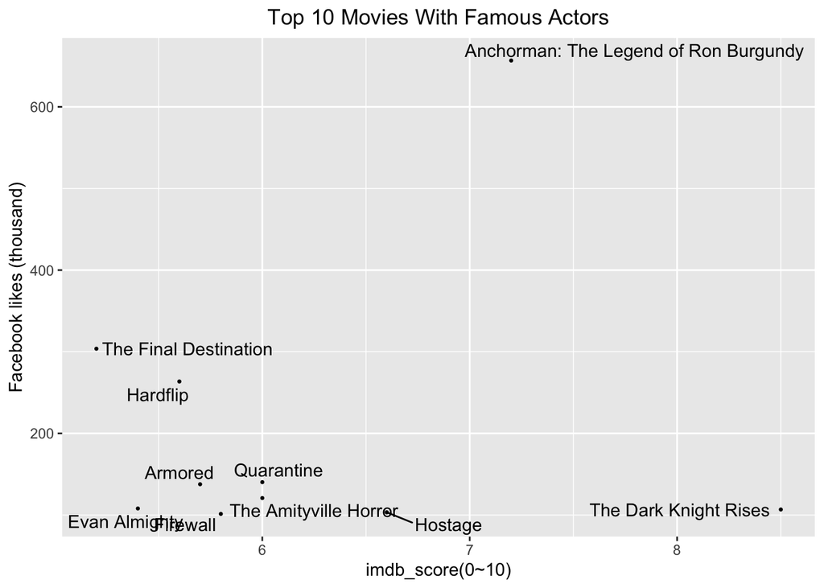

```r
imdb_df %>%
  filter(title_year %in% c(2000:2016)) %>%
  arrange(desc(cast_total_facebook_likes)) %>%
  top_n(10, cast_total_facebook_likes) %>%
  ggplot(aes(x=imdb_score, y=cast_total_facebook_likes/1000)) +
  geom_point(size=0.5) +
  geom_text_repel(aes(label=movie_title)) +
  labs(x = "imdb_score(0~10)", y = "Facebook likes (thousand)", title = "Top 10 Movies With Famous Actors") +
  theme(plot.title = element_text(hjust = 0.5))
```

演員知名度越高，不代表 IMDb score 越高。兩者並無顯著的直接關係。